# PRINCIPAL COMPONENT ANALYSIS

Or How to Find Structure in Variables

Marco R. Steenbergen

steenbergen@ipz.uzh.ch

University of Zurich

July 30, 2026

## R Packages

- `missMDA` for cross-validation.
- `psych` for parallel analysis, rotation, and component scores.

# Objective

## What Is Principal Component Analysis?

- Principal component analysis (PCA) is a data reduction technique first introduced by Pearson (1901):
  - We reduce the effective number of variables
- Consider the placement of German political parties on three issues $\rightarrow \mathbb{R}^3$.
- Is there a $\mathbb{R}^2$ or $\mathbb{R}^1$ space that adequately accounts for the data?

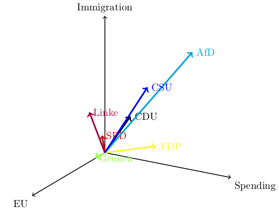

## What Does PCA Accomplish?

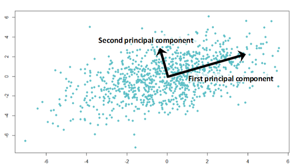

**Source:** [Analytics Vidhya](https://www.analyticsvidhya.com/blog/2016/03/pca-practical-guide-principal-component-analysis-python/)

Transform a set of correlated features into a smaller set of **principal components** with the following properties:

1. They are orthogonal.
2. They are extracted in the order of the variance for which they account.

# The Mathematics of PCA

## Spectral Decomposition

- Math
- Data
- Decomposition

For a $P \times P$ covariance matrix $\boldsymbol{S}$, we perform the spectral decomposition

$$\boldsymbol{S} = \boldsymbol{C} \boldsymbol{L} \boldsymbol{C}^\top = \sum_{j=1}^P \lambda_j \boldsymbol{c}_j \boldsymbol{c}_j^\top$$

Here,

- $\boldsymbol{L}$ is a diagonal matrix of eigenvalues, whose elements are $\lambda_j$.
- $\boldsymbol{C}$ is a $P \times P$ orthogonal matrix of **eigenvectors**, whose rows correspond to the features and whose columns correspond to the components. Each column has unit length.
- The **loadings** are the eigenvectors rescaled by the square root of their eigenvalues, $\boldsymbol{\Lambda} = \boldsymbol{C} \boldsymbol{L}^{1/2}$. These—not $\boldsymbol{C}$—are what we interpret and rotate.

```r
german_df <- data.frame(
  EU = c(6.38,6.38,5.69,6.23,3.00,4.85,1.62),
  spending = c(5.73,3.45,7.36,2.82,0.50,6.18,7.89),
  immigration = c(5.73,3.91,3.60,2.09,4.00,7.45,9.30)
)
row.names(german_df) <- c("CDU", "SPD", "FDP", "Gruenen", "Linke", "AfD",
                          "CSU")
S <- cov(german_df)
S
```

```
                    EU   spending immigration
EU           3.5235810 -0.5432881   -2.968743
spending    -0.5432881  7.1813905    4.207548
immigration -2.9687429  4.2075476    6.245829
```

```r
sd <- eigen(S)
sd
```

```
eigen() decomposition
$values
[1] 11.6778115  4.4182052  0.8547833

$vectors
           [,1]       [,2]       [,3]
[1,]  0.2924737 -0.6993803  0.6521705
[2,] -0.6719890 -0.6355302 -0.3801739
[3,] -0.6803602  0.3270605  0.6558517
```

## Total Variance and Variance Accounted For

- The **total variance** is the diagonal sum over $\boldsymbol{S}$: $\sum_{j=1}^P s_{jj}$.
- Mathematically, $\sum_{j=1}^P \lambda_j = \sum_{j=1}^P s_{jj}$.
- Thus, the $i$th component accounts for $100 \cdot \frac{\lambda_i}{\sum_j s_{jj}}$ percent of the total variance.

## PCA as a Model

- Principal components are linear composites.
- Specifically, unit $i$’s score on the $m$th component is

  $$p_{im} = \sum_{j=1}^P w_{jm} \cdot x_{ij}$$

  where $w_{jm}$ is the weight attached to feature $j$ by component $m$.
- For the unrotated solution these weights are just the elements of the $m$th eigenvector. Using the covariance decomposition above, a German party’s score on the 1st component is $0.292 \cdot \text{EU} - 0.672 \cdot \text{spend} - 0.680 \cdot \text{immigration}$.

## Contrast with Factor Analysis

[figure not shown]

## Covariance versus Correlation

- We used the covariance matrix to explain the idea of total variance.
- In general, PCAs are run on correlation matrices to accommodate differences in measurement scales.
- From now on, we shall follow suit.
- *Note:* For a correlation matrix, the total “variance” is equal to $P$.

## Implementation in R

- Syntax
- Result

```r
# Can be done from raw data. Here, we standardize,
pca_fit <- prcomp(german_df, center = TRUE, scale. = TRUE)
```

```r
pca_fit$rotation
```

```
                   PC1          PC2        PC3
EU          -0.5163756 -0.704454919  0.4869286
spending     0.5134001 -0.709748156 -0.4823670
immigration  0.6854025  0.000906648  0.7281638
```

# PCA and Data Reduction

## Back to the Original Goal

- The spectral decomposition extracts as many components as there are variables.
- If we are willing not to recover the total variance, however, it is possible to extract $M < P$ components.
- This data reduction serves several purposes
  - Can be used to reduce model complexity by combining features (`step_pca` in a `tidymodels` recipe).
  - Reveals connections among variables $\rightarrow$ new insights.
- The practical question is how to choose $M$.

## Choosing $M$

- Different methods are available:
  1. Variance explained.
  2. Eigenvalues.
  3. Scree plot
  4. Parallel analysis
  5. Cross-validation
- Best used with standardized features.

## Variance Explained

- Logic
- Result
- Components are extracted in the order of total variance they account for.
- Together, $P$ components account for 100% of the total variance.
- Often we are satisfied with 95% of the variance explained $\rightarrow$ we can drop components.

```r
summary(pca_fit)
```

```
Importance of components:
                          PC1    PC2     PC3
Standard deviation     1.3955 0.9445 0.40081
Proportion of Variance 0.6491 0.2973 0.05355
Cumulative Proportion  0.6491 0.9465 1.00000
```

Together the first two components account for 95% of the variance. Do we really need to retain the third component? If not $\mathbb{R}^3 \rightarrow \mathbb{R}^2$.

## Eigenvalue Cutoffs

- Logic
- Implementation
- Kaiser (1960) argued that we should reference the average eigenvalue of a correlation matrix, which is 1.
- Hence $\lambda_j > 1$ is used to select the number of components.
- Jolliffe (2002) sets a more lenient cutoff of 0.7.

[output not shown]

Kaiser: Retain one component.

Jolliffe: Retain two components.

## Screeplot

- Logic
- Syntax
- Result
- Cattell (1966) introduced the screeplot: plot components on the $x$ axis and eigenvalues on the $y$-axis.
- Look for the elbow in the plot: fast drop makes places for shallower drops $\rightarrow$ additional components do not add all that much.

```r
screeplot(pca_fit)
```

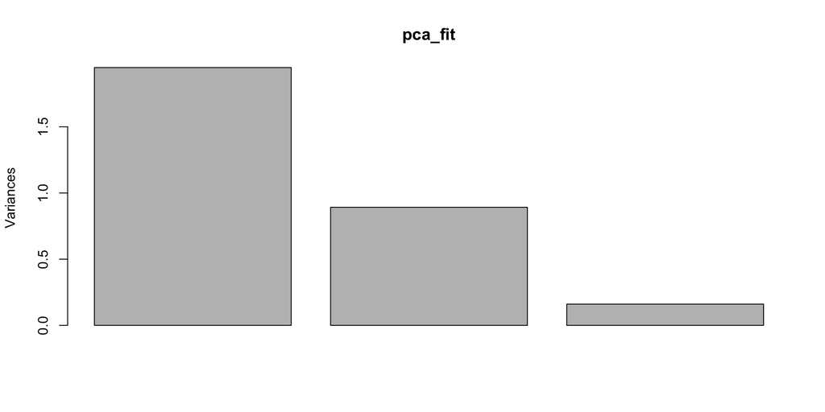

## Parallel Analysis

- Logic
- Syntax
- Result
- Horn (1965) proposed parallel analysis,
- Simulates random data matrices of identical dimensions ($n \times p$) drawn from uncorrelated standard normal distributions.
- *Decision Rule:* Compare the observed eigenvalues to the average (or 95th percentile) eigenvalues generated from the simulated random data. Retain components whose empirical eigenvalues strictly exceed the simulated values.
- *Caveat:* Our example has $n = 7$ and $p = 3$, which is far too small. The simulation is not identified, `fa.parallel` returns 0 components, and it warns about a Heywood case. Read the next tab as a demonstration of syntax, not as evidence about $M$.

```r
library(psych)
fa.parallel(cor(german_df), n.obs = 7, fa = "pc")
```

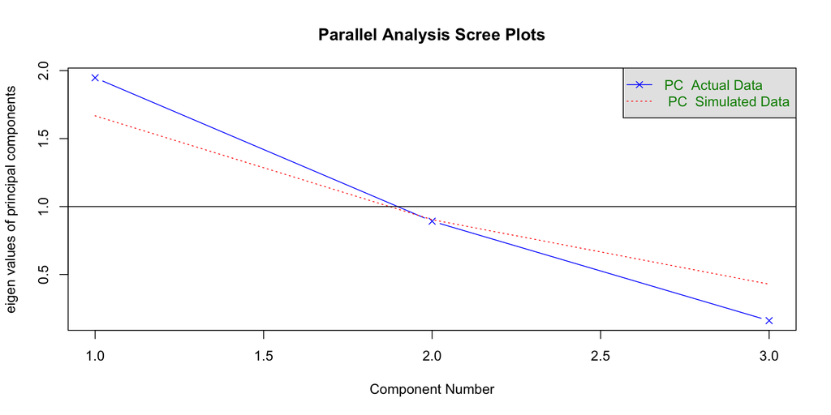

```
Parallel analysis suggests that the number of factors =  NA  and the number of components =  0
```

## Cross-Validation

- Logic
- Syntax
- Results
- Josse and Husson (2012) and Wold (1978) propose cross-validation for selecting $M$.
- *Method:* Treat PCA as a matrix approximation problem. Withhold a fraction of elements or rows, fit PCA on the remaining data using $M$ components, and evaluate the reconstruction error (e.g., PRESS - Predicted Residual Error Sum of Squares) on the held-out values.
- *Decision Rule:* Select $M$ that minimizes the cross-validation reconstruction error or uses the “one standard error rule.”

```r
library(missMDA)
cv_res <- estim_ncpPCA(german_df,
                       ncp.min = 1, ncp.max = 3,
                       method.cv = "Kfold")
cv_res$ncp
```

```
[1] 1
```

## Where Does This Leave Us

# Interpreting Components

## Rotation

- We can use the loadings to make sense of the principal components.
- However, the loadings are *not* unique.
- We can account for the same portion of $T$ through arbitrary orthogonal transformations of $\boldsymbol{C}$ that we call **rotations**.
- Rotation is our friend—a carefully selected rotation can simplify the interpretation.

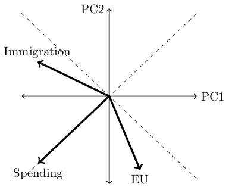

## Varimax Rotation

- Varimax is a rotation method that rotates the axes while preserving orthogonality (Kaiser 1958).
- Raw principal components prioritize mathematical variance, often leaving data points floating between axes.
- Varimax turns the grid so each axis points directly toward a cluster of variables.
- It maximizes loading variance: pushing strong relationships near **+1 or -1** and weak ones near **0**. Each original variable becomes tied primarily to a single factor.

## Varimax in Action

- Syntax
- Result
- Pitfall

```r
# Settling on M = 2 components. principal() standardizes by default and
# rotates the loadings, which is what varimax requires.
pca_rotate <- principal(german_df, nfactors = 2, rotate = "varimax")
```

```r
# cutoff = 0 because psych blanks |loading| < 0.1 by default
print(pca_rotate$loadings, cutoff = 0)
```

```
Loadings:
            RC1    RC2
EU           0.980 -0.034
spending    -0.038  0.980
immigration -0.681  0.672

                 RC1   RC2
SS loadings    1.425 1.414
Proportion Var 0.475 0.471
Cumulative Var 0.475 0.946
```

EU and spending each load on one component only; immigration is a roughly equal blend of both.

- Varimax must rotate the **loadings**, never the eigenvectors.
- Moving to the `psych` package is the easiest way of doing this.

# Using Components

## Component Scores

- Once we have decided to reduce from $P$ to $M < P$, we discard the original variables.
- Instead, we work with the scores on the principal components using the model

  $$p_{im} = \sum_{j=1}^P w_{jm} \cdot z_{ij}$$

  for $m = 1, \cdots, M < P$, where the $z_{ij}$ are the standardized features.
- The scoring weights are $\boldsymbol{W} = \boldsymbol{R}^{-1} \boldsymbol{\Lambda}$. They are *not* the loadings; `psych` keeps them in `$weights`.

## Component Scores in `psych`

- Syntax
- Result
- Correlation Input

```r
# pca_rotate was fitted from raw data, so the scores come along for free
pca_rotate$scores
```

```
               RC1        RC2
CDU      0.6373290  0.5566584
SPD      0.6650024 -0.3690690
FDP      0.8083544  0.6459239
Gruenen  0.7940923 -0.8281199
Linke   -1.0596539 -1.7158469
AfD     -0.2006009  0.7069647
CSU     -1.6445233  1.0034888
```

[output not shown]

- Scores require the raw observations. A fit to a correlation matrix has none, so it carries no scores:

```r
pca_cor <- principal(cor(german_df), nfactors = 2)
is.null(pca_cor$scores)
```

```
[1] TRUE
```

- Supply the data separately to recover them:

```r
sc <- factor.scores(german_df, pca_cor)
round(sc$scores, 2)
```

```
          RC1   RC2
CDU      0.64  0.56
SPD      0.67 -0.37
FDP      0.81  0.65
Gruenen  0.79 -0.83
Linke   -1.06 -1.72
AfD     -0.20  0.71
CSU     -1.64  1.00
```

## Exercise

**Your Turn**

Perform a PCA on the predictive features from the Boston Housing data. How many components would you retain? What do they mean?

## References

Cattell, Raymond B. 1966. “The Scree Test for the Number of Factors.” *Multivariate Behavioral Research* 1 (2): 245–76. https://doi.org/10.1207/s15327906mbr0102_10.

Horn, John L. 1965. “A Rationale and Test for the Number of Factors in Factor Analysis.” *Psychometrika* 30 (2): 179–85. https://doi.org/10.1007/BF02289447.

Jolliffe, I. T. 2002. *Principal Component Analysis*. 2nd ed. Springer Series in Statistics. Springer.

Josse, Julie, and François Husson. 2012. “Selecting the Number of Components in Principal Component Analysis Using Cross-Validation Approximations.” *Computational Statistics & Data Analysis* 56 (6): 1869–79. https://doi.org/10.1016/j.csda.2011.11.012.

Kaiser, Henry F. 1958. “The Varimax Criterion for Analytic Rotation in Factor Analysis.” *Psychometrika* 23 (3): 187–200. https://doi.org/10.1007/BF02289233.

Kaiser, Henry F. 1960. “The Application of Electronic Computers to Factor Analysis.” *Educational and Psychological Measurement* 20 (1): 141–51. https://doi.org/10.1177/001316446002000116.

Pearson, Karl. 1901. “On Lines and Planes of Closest Fit to Systems of Points in Space.” *The London, Edinburgh, and Dublin Philosophical Magazine and Journal of Science* 2 (11): 559–72. https://doi.org/10.1080/14786440109462720.

Wold, Svante. 1978. “Cross-Validatory Estimation of the Number of Components in Factor and Principal Components Models.” *Technometrics* 20 (4): 397–405. https://doi.org/10.1080/00401706.1978.10489693.